# R Data Analysis Portfolio

Syed Absar Ali

Welcome to my portfolio, showcasing projects and analyses I have conducted using R, highlighting my skills in statistical programming, data cleaning, analysis, and visualization.

- R Shiny KPI Dashboard
- World Trade Report 2022
- COVID-19 Survey Analysis for UNICEF
- Case for Reduction in PSF Import Duty
- Pakistan Stock Exchange Web Scraper

## R Shiny KPI Dashboard

My first R project was an R Shiny dashboard for the Center for Economic Research in Pakistan. This internal resource pulled data from various sources in real-time to provide an overview of project KPIs. I self-taught R specifically for this project and learned it through its development.

[Click here to visit the dashboard and get an in-app tutorial](https://absar95.shinyapps.io/Platform_Analytics/).

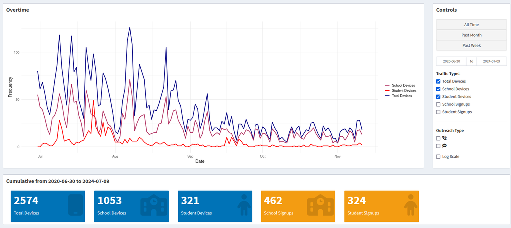

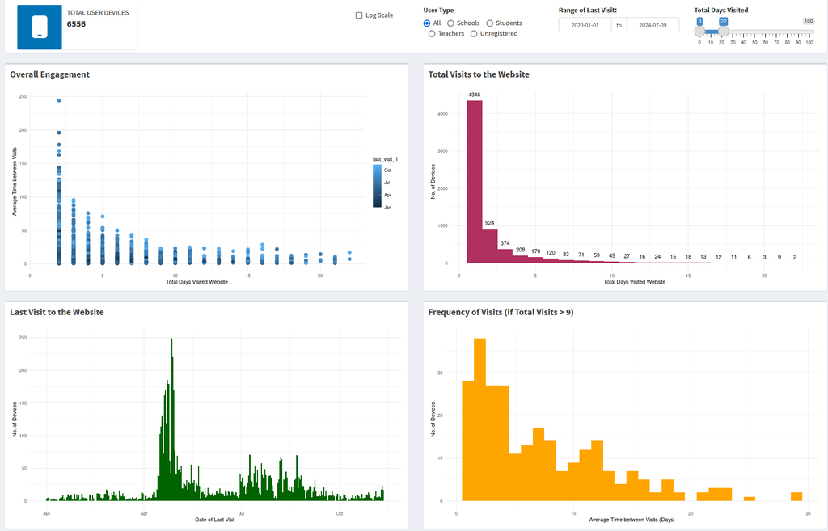

### World Trade Report 2022

I conducted several analyses and created visualizations for the World Trade Report 2022.

**Analysis & Visualization in R**

**Processed for Publication in WTR22**

[figure not shown]

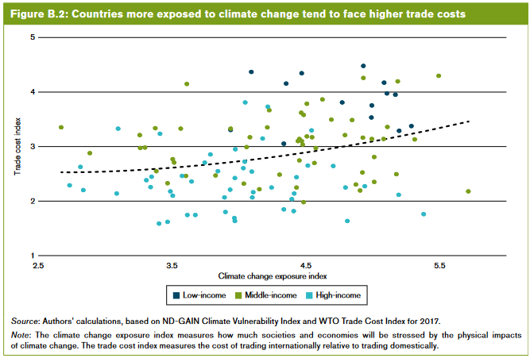

A notable example was replicating Shapiro’s (2021) analysis, which showed that carbon-intensive manufacturing industries face lower trade costs using the WTO Trade Costs Index. I used MATLAB and STATA to calculate carbon intensities with input-output tables and conducted the remaining analysis in R.

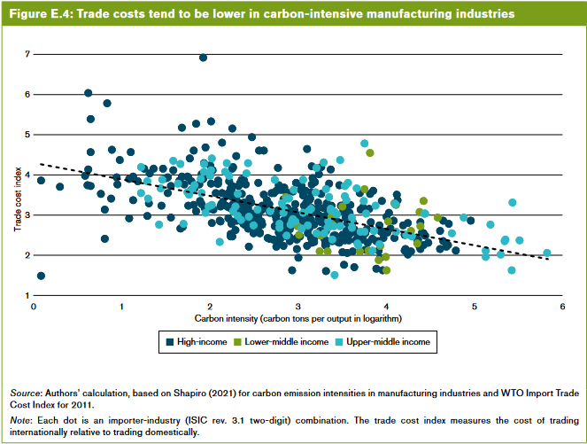

Other examples:

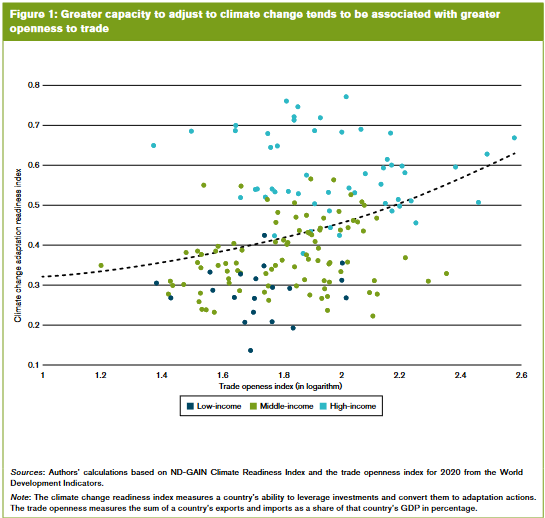

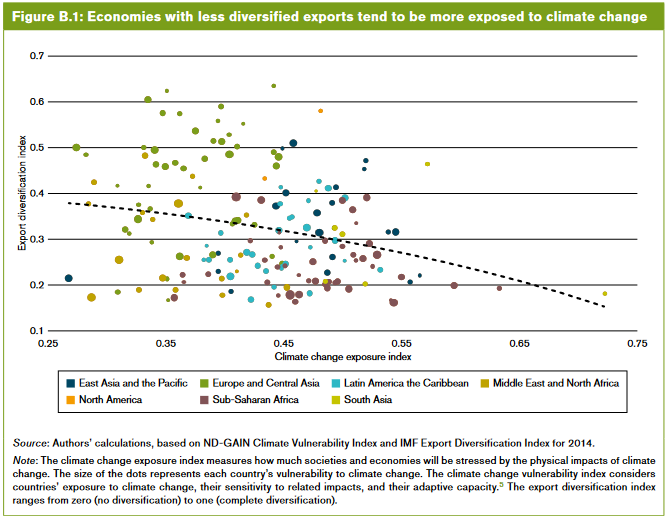

### COVID-19 Survey Analysis for UNICEF

Select plots I created for UNICEF’s Risk Communication and Community Engagement program, studying drivers of COVID-19 perceptions and behaviors to inform information dissemination campaigns. The project involved creating up to 70 unique plots for each of 6 survey rounds, plus trends over time and regression analysis to determine causality. The data was entirely categorical and required extensive cleaning and preparation for analysis.

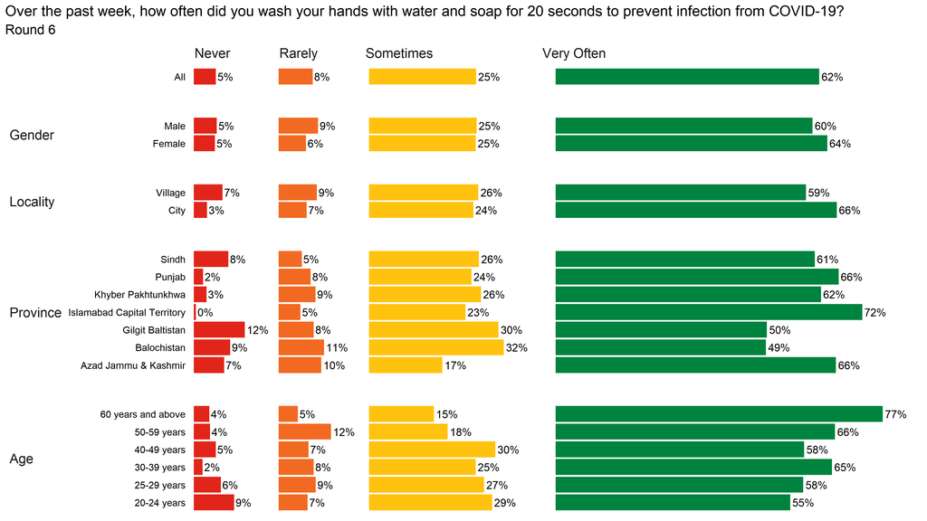

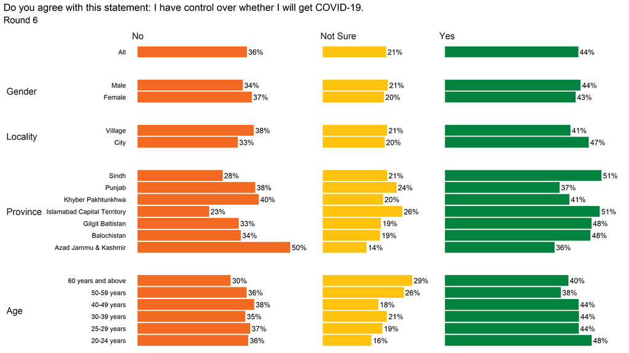

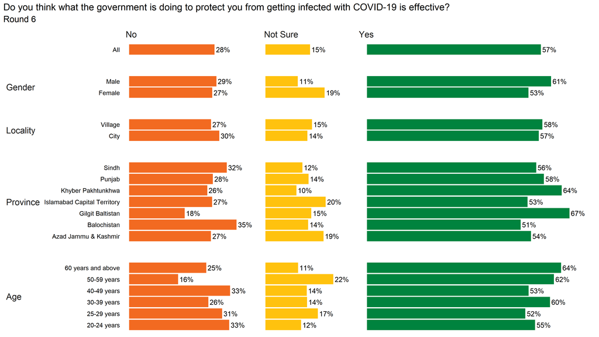

```r
plot_1_function <- function(variable, plot_title, round, no, ns, yes) {

  # Select variable and prepare breakdown by key demographics

  plot_data <- round6 %>%
    filter(round == round) %>%
    mutate(all = "All") %>%
    dplyr::select(all,
                  province,
                  gender,
                  age,
                  locality,!!as.symbol(variable),
                  Wt) %>%
    pivot_longer(
      cols = c("all",
               "province",
               "gender",
               "age",
               "locality"),
      names_to = "group",
      values_to = "demographic"
    ) %>%
    group_by(group, demographic) %>%
    mutate(Sum_Wt = sum(Wt), percent = Wt / Sum_Wt * 100) %>%
    group_by(group, demographic,!!as.symbol(variable)) %>%
    summarise(percent = sum(percent)) %>%
    mutate(
      group = case_when(
        group == "age" ~ "Age",
        group == "all" ~ "",
        group == "gender" ~ "Gender",
        group == "locality" ~ "Locality",
        group == "province" ~ "Province"
      ),
      group = factor(group, levels = c(
        "", "Gender", "Locality", "Province", "Age"
      ))
    ) %>% group_by(!!as.symbol(variable)) %>% mutate(ylim = max(percent) + 5)

  ## Plot data

  ggplot(data = plot_data,
         aes(
           x = percent,
           y = demographic,
           fill = !!as.symbol(variable)
         )) + geom_col(width = 0.9) + geom_text(
           aes(label = paste(round(percent), "%", sep = "")),
           size = 4,
           hjust = -0.1,
           color = "black"
         ) + scale_fill_manual(values = c(orange,
                                          yellow,
                                          green)) + facet_grid(
                                            rows = vars(group),
                                            cols = vars(!!as.symbol(variable)),
                                            scales = "free",
                                            space = "free",
                                            switch = "y"
                                          ) + labs(title = plot_title,
                                                   subtitle = paste("Round", round, sep = " ")) +
    theme(
      panel.background = element_blank(),
      panel.spacing.y = unit(2, "lines"),
      axis.text.x = element_blank(),
      axis.text.y = element_text(size = 10, color = "black"),
      axis.ticks = element_blank(),
      axis.title = element_blank(),
      legend.position = "none",
      strip.background = element_blank(),
      strip.placement = "outside",
      strip.text.x = element_text(size = 14, hjust = 0),
      strip.text.y.left = element_text(
        size = 14,
        hjust = 0,
        angle = 360
      ),
      plot.title = element_text(size = 15),
      plot.subtitle = element_text(size = 14),
      plot.title.position = "plot"
    ) + geom_blank(aes(x = 0)) +
    geom_blank(aes(x = ylim))

  write.csv(plot_data,
            paste("R6_visuals/csv/", variable, "_plot.csv"),
            row.names = FALSE)
  ggsave(
    paste("R6_visuals/svg/", variable, "_plot.svg", sep = ""),
    last_plot(),
    device = "svg",
    width = unit(13.33, "in"),
    height = unit(7.5, "in")
  )
  ggsave(
    paste("R6_visuals/png/", variable, "_plot.png", sep = ""),
    last_plot(),
    device = "png",
    width = unit(13.33, "in"),
    height = unit(7.5, "in")
  )

}
```

### Case for Reduction in PSF Import Duty

The following analyses and visualizations are part of the knowledge capital I have developed for APTMA, regularly used in reports, briefs and media pieces to advocate for rationalization of the PSF import duty.

Despite being one of the top exporters of textiles and apparel, Pakistan’s share in the international market is very low. One reason for this is low product diversification; 67% of exports are cotton-based, while the global market is evenly divided among cotton, man-made fibers, and other materials. MMF-based manufacturing is not competitive due to an 18% import duty (CD+ADD) on polyester staple fiber, a crucial raw material. Additionally, three local producers exploit this protection to artificially inflate domestic PSF prices.

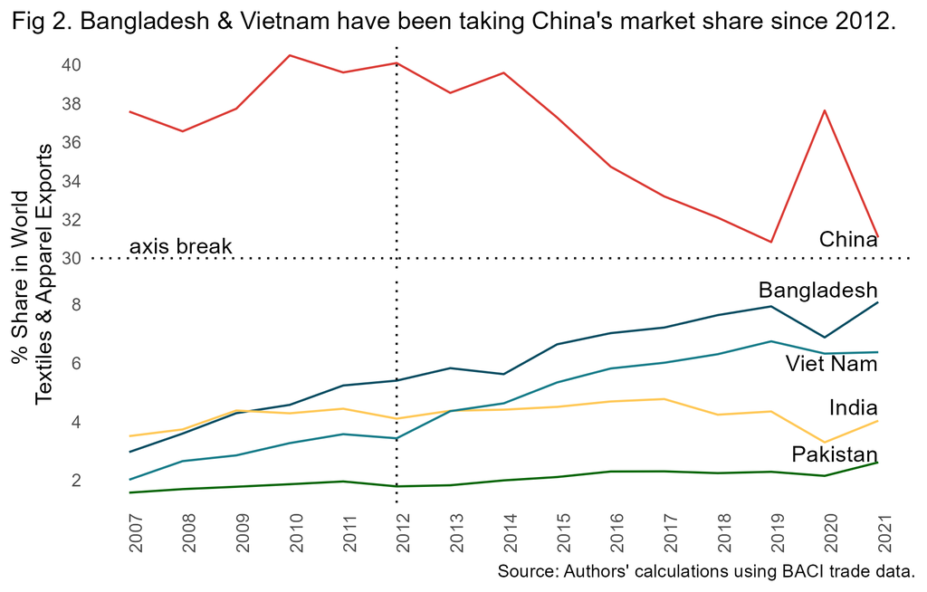

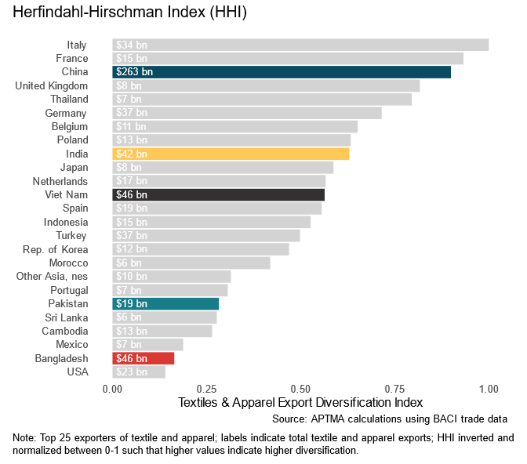

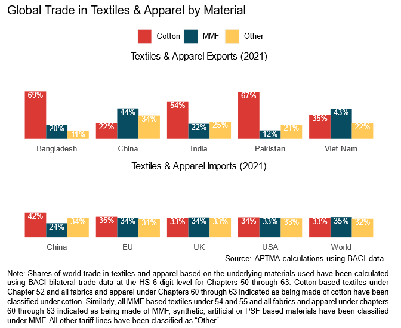

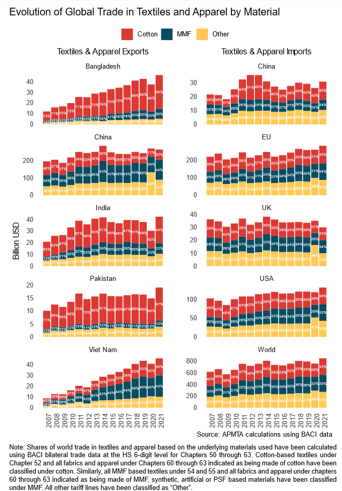

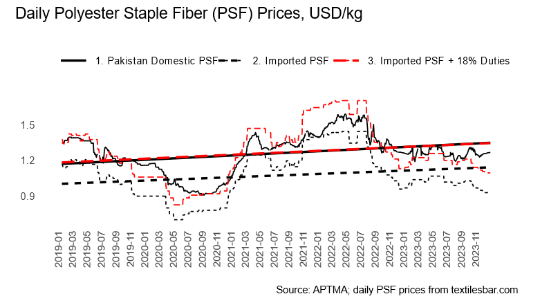

```r
# Calculate textile and apparel import and shares by material ----

## Import share calculations for select countries ----

import.share.fun <- function(year = 2021) {

  read.csv(
    paste(
      "data/BACI_HS07_V202301/BACI_HS07_Y", year, "_V202301.csv",
      sep = ""
    )
  ) %>%
    as_tibble() %>%
    mutate(
      k = as.character(k),
      k = if_else(
        str_length(k) == 5, paste("0", k, sep = ""), k
      )
    ) %>% filter(
      as.numeric(str_sub(k, 1, 2)) >= 50 & as.numeric(str_sub(k, 1, 2) <= 63)
    ) %>%
    left_join(
      read.csv("data/BACI_HS17_V202301/country_codes_V202301.csv") %>%
        rename(
          "i" = "country_code",
          "country.i" = "country_name_abbreviation",
          "EU.i" = "EU"
        ) %>% select(i, country.i, EU.i),
      by = "i"
    ) %>%
    left_join(
      read.csv("data/BACI_HS17_V202301/country_codes_V202301.csv") %>%
        rename(
          "j" = "country_code",
          "country.j" = "country_name_abbreviation",
          "EU.j" = "EU"
        ) %>% select(j, country.j, EU.j),
      by = "j"
    ) %>% filter(
      country.j == "USA" | country.j == "China" |
        country.j == "United Kingdom" | EU.j == 1
    ) %>% group_by(country.j, k) %>%
    summarise(v = sum(v)) %>%
    left_join(
      read.csv("data/fabric_classes.csv") %>%
        pivot_longer(cotton:artificial) %>%
        filter(!is.na(value)) %>%
        mutate(k = as.character(value), class = name) %>%
        select(k, class),
      by = "k"
    ) %>% mutate(
      class = if_else(
        str_sub(k, 1, 2) == "52", "cotton", if_else(
          str_sub(k, 1, 2) == "54" | str_sub(k, 1, 2) == "55", "mmf",
          if_else(is.na(class), "Other", class)
        )
      )
    ) %>% mutate(
      class = str_to_title(class),
      class = case_when(
        class == "Mmf" ~ "MMF",
        class == "Artificial" ~ "MMF",
        class == "Synthetic" ~ "MMF",
        class == "Cotton" ~ "Cotton",
        class == "Other" ~ "Other"
      )
    ) %>%
    group_by(country.j, class) %>% summarise(v = sum(v)) %>%
    ungroup() %>%
    mutate(
      country.j = if_else(
        country.j == "USA", "USA", if_else(
          country.j == "China", "China", if_else(
            country.j == "United Kingdom", "United Kingdom", "EU"
          )
        )
      )
    ) %>%
    group_by(country.j, class) %>%
    summarise(v = sum(v)) %>%
    group_by(country.j) %>%  mutate(percent = v/sum(v) * 100) %>%
    ungroup() %>% mutate(year = year)

}

raw.import.shares <- lapply(c(2007:2021), import.share.fun) # Calculate annual import shares for 2007-2021

## Export share calculations for select countries ----

export.share.fun <- function(year = 2021) {

  read.csv(
    paste(
      "data/BACI_HS07_V202301/BACI_HS07_Y", year, "_V202301.csv",
      sep = ""
    )
  ) %>% as_tibble() %>%
    mutate(
      k = as.character(k),
      k = if_else(str_length(k) == 5, paste("0", k, sep = ""), k)
    ) %>% filter(
      as.numeric(str_sub(k, 1, 2)) >= 50 &
        as.numeric(str_sub(k, 1, 2) <= 63)
    ) %>%
    left_join(
      read.csv("data/BACI_HS17_V202301/country_codes_V202301.csv") %>%
        rename(
          "i" = "country_code",
          "country.i" = "country_name_abbreviation",
          "EU.i" = "EU"
        ) %>% select(i, country.i, EU.i),
      by = "i"
    ) %>%
    left_join(
      read.csv("data/BACI_HS17_V202301/country_codes_V202301.csv") %>%
        rename(
          "j" = "country_code",
          "country.j" = "country_name_abbreviation",
          "EU.j" = "EU"
        ) %>% select(j, country.j, EU.j),
      by = "j"
    ) %>% filter(
      country.i == "Pakistan" | country.i == "India" |
        country.i == "Bangladesh" | country.i == "Viet Nam" |
        country.i == "China" | country.i == "Indonesia" | country.i == "Turkey"
    ) %>% group_by(country.i, k) %>%
    summarise(v = sum(v)) %>%
    left_join(
      read.csv("data/fabric_classes.csv") %>%
        pivot_longer(cotton:artificial) %>%
        filter(!is.na(value)) %>%
        mutate(k = as.character(value), class = name) %>%
        select(k, class),
      by = "k"
    ) %>% mutate(
      class = if_else(
        str_sub(k, 1, 2) == "52", "cotton", if_else(
          str_sub(k, 1, 2) == "54" | str_sub(k, 1, 2) == "55", "mmf",
          if_else(is.na(class), "Other", class)
        )
      )
    ) %>% mutate(
      class = str_to_title(class),
      class = case_when(
        class == "Mmf" ~ "MMF",
        class == "Artificial" ~ "MMF",
        class == "Synthetic" ~ "MMF",
        class == "Cotton" ~ "Cotton",
        class == "Other" ~ "Other"
      )
    ) %>%
    group_by(country.i, class) %>% summarise(v = sum(v)) %>%
    group_by(country.i, class) %>%
    summarise(v = sum(v)) %>%
    group_by(country.i) %>% mutate(percent = v/sum(v) * 100) %>%
    ungroup() %>% mutate(year = year)

}

raw.export.shares <- lapply(c(2007:2021), export.share.fun) # Calculate annual export shares for 2007-2021

## Combine country and world import shares ----

import.shares <- rbind(
  do.call(rbind, raw.import.shares),
  do.call(rbind, raw.import.shares.world) %>%
    mutate(country.j = "World") %>% relocate(country.j)
) %>%
  mutate(
    country.j = case_when(
      country.j == "China" ~ "China",
      country.j == "EU" ~ "EU",
      country.j == "United Kingdom" ~ "UK",
      country.j == "USA" ~ "USA",
      country.j == "World" ~ "World"
    )
  )

## Combine country and world export shares ----

export.shares <- rbind(
  do.call(rbind, raw.export.shares),
  do.call(rbind, raw.import.shares.world) %>%
    mutate(country.j = "World") %>% relocate(country.j) %>%
    rename("country.i" = "country.j")
) %>% filter(
  country.i == "Pakistan" | country.i == "Bangladesh" | country.i == "China" |
    country.i == "India" | country.i == "Viet Nam"
)

# Plot import shares

p.data <- import.shares
import.shares.plot <- ggplot(
  import.shares, aes(x = year, y = v/1000000, fill = class)
) + geom_col() +
  facet_wrap(vars(country.j), ncol = 1, scales = "free_y") +
  line.theme.date.csubtitle + labs(
    y = "",
    caption = "Source: APMTA calculations using BACI data",
    subtitle = "Textiles & Apparel Imports"
  ) + scale_x_continuous(
    breaks = seq(min(p.data$year), max(p.data$year), by = 1)
  ) + scale_fill_manual(values = c(red, blue, yellow)) +
  geom_text(
    aes(
      label = paste(round(percent), "%", sep = "")
    ), size = 1.7, position = position_stack(vjust = 0.5), color = "white"
  )
```

```r
# Plot export shares

p.data <- export.shares
export.shares.plot <- ggplot(
  export.shares, aes(x = year, y = v/1000000, fill = class)
) + geom_col(aes()) +
  facet_wrap(vars(country.i), ncol = 1, scales = "free_y") +
  line.theme.date.csubtitle + labs(
    y = "Billion USD",
    caption = "",
    subtitle = "Textiles & Apparel Exports"
  ) + scale_x_continuous(
    breaks = seq(min(p.data$year), max(p.data$year), by = 1)
  ) + scale_fill_manual(values = c(red, blue, yellow)) +
  geom_text(
    aes(
      label = paste(round(percent), "%", sep = "")
    ), size = 1.7, position = position_stack(vjust = 0.5), color = "white"
  )

# Combine import and export plots for market shares over time

ggarrange(
  export.shares.plot,
  import.shares.plot,
  common.legend = TRUE
)

ggsave("plots/new_gov_agenda/exim_shares_time.png", h = 8, w = 6.27, units = "in" )
ggsave("plots/new_gov_agenda/fig_5.svg", h = 8, w = 6.27, units = "in" )

## Plot import and export shares for 2021

export.shares.2021 <- ggplot(
  export.shares %>% filter(year == 2021), aes(x = country.i, y = percent)
) + geom_col(aes(fill = class), position = "dodge") +
  theme(
    panel.background = element_blank(),
    axis.ticks = element_blank(),
    legend.position = "top",
    legend.title = element_blank(),
    axis.title.x = element_blank(),
    axis.text.y = element_blank(),
    axis.title.y = element_blank(),
    plot.subtitle = element_text(hjust = 0.5)
  ) + scale_fill_manual(values = c(red, blue, yellow)) +
  labs(
    y = "Percent",
    subtitle = "Textiles & Apparel Exports (2021)"
  ) + geom_text(
    aes(label = paste(round(percent), "%", sep = ""), group = class),
    position = position_dodge(width = 0.9), vjust = 1.2, color = "white",
    size = 3
  ) + ylim(0, 100)

import.shares.2021 <- ggplot(
  import.shares %>% filter(year == 2021), aes(x = country.j, y = percent)
) + geom_col(aes(fill = class), position = "dodge") +
  theme(
    panel.background = element_blank(),
    axis.ticks = element_blank(),
    legend.position = "top",
    legend.title = element_blank(),
    axis.title.x = element_blank(),
    axis.text.y = element_blank(),
    axis.title.y = element_blank(),
    plot.subtitle = element_text(hjust = 0.5)
  ) + scale_fill_manual(values = c(red, blue, yellow)) +
  labs(
    subtitle = "Textiles & Apparel Imports (2021)",
    y = "Percent",
    caption = "Source: APTMA calculations using BACI data"
  ) + geom_text(
    aes(label = paste(round(percent), "%", sep = ""), group = class),
    position = position_dodge(width = 0.9), vjust = 1.2, color = "white",
    size = 3
  ) + ylim(0, 100)

ggarrange(
  export.shares.2021,
  import.shares.2021,
  common.legend = TRUE,
  nrow = 2
)

ggsave("plots/new_gov_agenda/exim_shares2021.png", h = 4, w = 6.27, units = "in")
ggsave("plots/new_gov_agenda/fig_4.svg", h = 4, w = 6.27, units = "in")

## Herfindahl-Hirchman Index Graph ----

data <- read.csv( # read BACI 2021 bilateral trade flows
  paste(
    "data/BACI_HS07_V202301/BACI_HS07_Y", 2021, "_V202301.csv",
    sep = ""
  )
)

# Prepare data and calcualte HHI

p.data <- data %>%
  as_tibble() %>%
  mutate(
    k = as.character(k),
    k = if_else(
      str_length(k) == 5, paste("0", k, sep = ""), k
    )
  ) %>% filter(
    as.numeric(str_sub(k, 1, 2)) >= 50 & as.numeric(str_sub(k, 1, 2) <= 63)
  ) %>%
  left_join(
    read.csv("data/BACI_HS17_V202301/country_codes_V202301.csv") %>%
      rename(
        "i" = "country_code",
        "country.i" = "country_name_abbreviation",
        "EU.i" = "EU"
      ) %>% select(i, country.i, EU.i),
    by = "i"
  ) %>% group_by(country.i, k) %>%
  summarise(v = sum(v)) %>% group_by(country.i) %>%
  mutate(total.export = sum(v)) %>%
  mutate( # Calculate HHI
    export.share = v/sum(v) * 100,
    export.share.sq = export.share*export.share
  ) %>% group_by(country.i) %>%
  summarise(hhi = 1/sum(export.share.sq)) %>%
  mutate( # variable to highlight select countries in plot
    color = if_else(
      country.i == "Pakistan", "A", if_else(
        country.i == "Bangladesh", "B", if_else(
          country.i == "India", "C", if_else(
            country.i == "China", "D", if_else(
              country.i == "Viet Nam", "E", "F"
            )
          )
        )
      )
    )
  ) %>% ungroup() %>% mutate(
    hhi.norm = (hhi - min(hhi))/(max(hhi) - min(hhi)) # Normalize HHI between 0-1
  ) %>% left_join(
    data %>%
      as_tibble() %>%
      mutate(
        k = as.character(k),
        k = if_else(
          str_length(k) == 5, paste("0", k, sep = ""), k
        )
      ) %>% filter(
        as.numeric(str_sub(k, 1, 2)) >= 50 & as.numeric(str_sub(k, 1, 2) <= 63)
      ) %>%
      left_join( # Add country names
        read.csv("data/BACI_HS17_V202301/country_codes_V202301.csv") %>%
          rename(
            "i" = "country_code",
            "country.i" = "country_name_abbreviation",
            "EU.i" = "EU"
          ) %>% select(i, country.i, EU.i),
        by = "i"
      ) %>% group_by(country.i) %>%
      summarise(v = sum(v)),
    by = "country.i"
  ) %>% arrange(-v)

## Make HHI plot ----

  ggplot(
    p.data %>% filter(row_number() <=25),
    aes(x = hhi.norm, y = reorder(country.i, hhi))
  ) + geom_col(aes(fill = color)) +
    theme(
      panel.background = element_blank(),
      legend.position = "off",
      axis.ticks = element_blank(),
      axis.title.y = element_blank()
    ) +
    scale_fill_manual(
      values = c(green, red, yellow, blue, grey, "lightgrey")
    ) + labs(
      x = "Textiles & Apparel Export Diversification Index",
      caption = "Source: APTMA calculations using BACI trade data"
    ) + geom_text(
      aes(label = paste("$", round(v/1000000), " bn", sep = ""), x = 0.01),
      hjust = 0, color = "white", size = 3
    )

  ggsave("plots/new_gov_agenda/hhi.png", h = 5, w = 6.27, units = "in")
  ggsave("plots/new_gov_agenda/fig_3.svg", h = 5, w = 6.27, units = "in")
```

### Pakistan Stock Exchange Web Scraper

A function to scrape key information about firms listed on the Pakistan Stock Exchange. It’s ready to run; just copy and paste it into your R console.

```r
library(tidyverse)
library(rvest)
library(shinyjs)

# A function that pulls tables on key information including profit, revenue, management, recent notices issued,
# etc., about firms listed on the Pakistan Stock Exchange
# Uses company symbol to visit PSX company profile and pull all html tables

scrape.psx <- function(symbol){
  print(paste("Starting ", symbol, sep = ""))
  link = paste(
    "https://dps.psx.com.pk/company/",
    symbol, sep = "")
  page <- read_html(link)
  tables <- page %>%
    html_elements(css = ".tbl__body") %>%
    html_table()
  print(paste(symbol, " Complete", sep = ""))
  return(tables)
  Sys.sleep(5)
}

scrape.psx("SCBPL") # Try function for Standard Chartered Bank Pakistan
```